# Ford GoBike (Bike Shares) Records Exploring

## Investigation Overview

In this investigation , I am interested to figure out the Top stations with highest Trip records and the average trip durations among those stations. in addition, I will explore other characteristics that could have an effect or relationships with the mention features of interest. Characteristics related to time like weekdays & day time) and others related to riders like ages , gender and user Type.

## Dataset Overview

The data consisted of bikes' trip records and attributes of 183412 Bikes' rental records for February 2019 in San Francisco with mainly 9 features (start_station_name, end_station_name, weekday, start_hour, bike_share_for_all_trip, member_gender, member_age(years), user_type and duration_min(min)). Most variables are Categorical, but the variables member_age(years) and duration_min(min) are numeric variables.

## Distribution of Trips Durations(min)

Distributions of Bikes Trip durations under logarithmic Scale are most likely normally distributed and mean of trips durations is around 9 minutes. there are few records (outliers) of trip duration more than 200min.

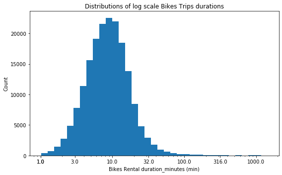

## Distribution of of riders' Ages(years)

Distributions of riders' Ages under logarithmic Scale are most likely normally distributed and and most of riders' ages are around 32 years old. There are few records (outliers) of memebers' ages more than 100 years old.

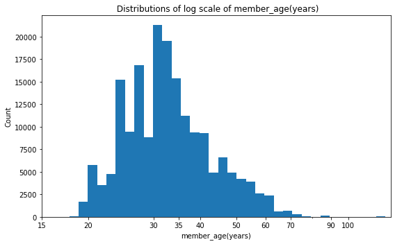

## Bikes Rents Distributions across Weedays & Day hours

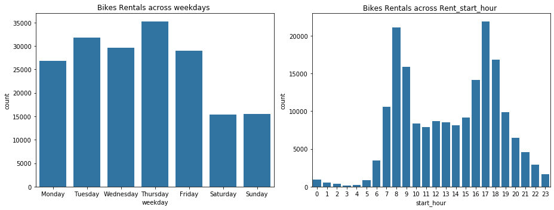

## Top 7 stations with highest Traffic(trips)

Below are Top 7 stations out of 329 start stations having the highest number of trips more than 2500. where 'Market St at 10th St' station has the highest number of trips. our comming analysis will be based on these Top 7 stations (highest traffic stations).

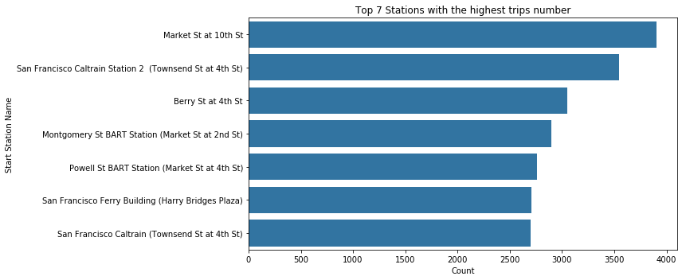

## Average Trip Duration per the Top 7 Station

we can observe that the average trip duration for 'San Francisco Ferry Building' is the longest trip with duration pf 14 minutes.

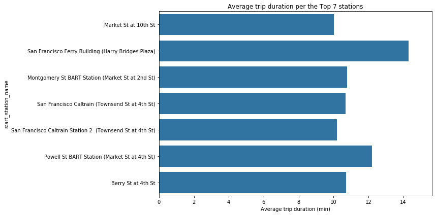

## Trip Duration vs. Memeber Age

Age has slight negative correlation with Trip duration.Assumed that older ages riders can not ride for long distance.

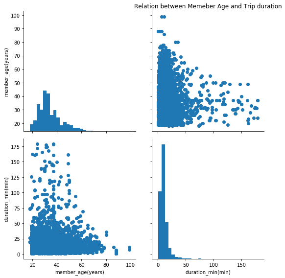

## Day time & Week days trips among The Top 7 stations

**Day Time:**

**Week days:**

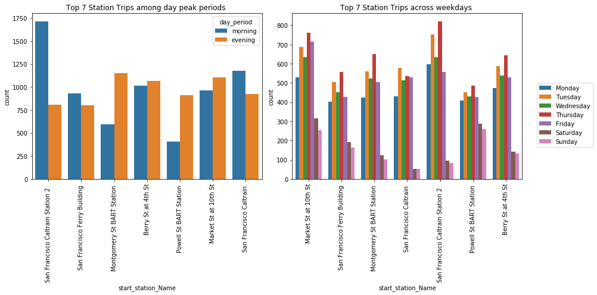

## Riders' gender & User Type among The Top 7 Stations

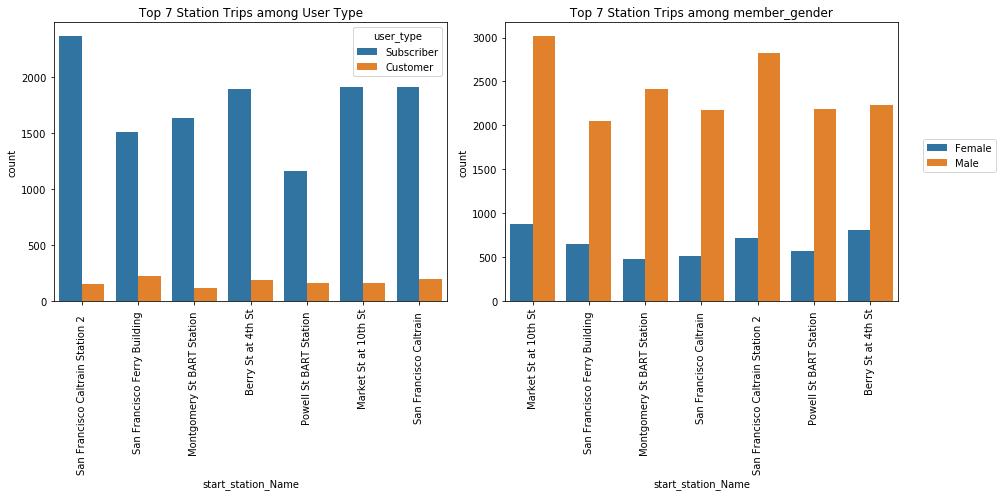

- Average trip duration during weekend is longer than normal week days.
- Average riders ages and it's distributions in weekends are younger than riders ages during normal week days mostly related to family trips during holidays.
- Average ages of male riders are older than female rider.
- Average Trip duration for females are slightly longer than males.

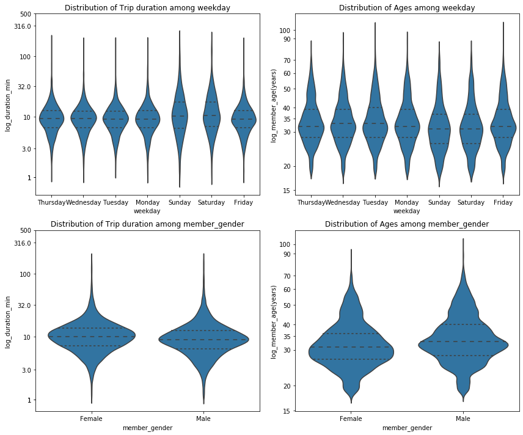

## Trip Durations among Weekdays per Gender

Average Trip duration for females are slightly longer than males for all weekdays. More likely that it is related to physical performance of males are better than female as nature.

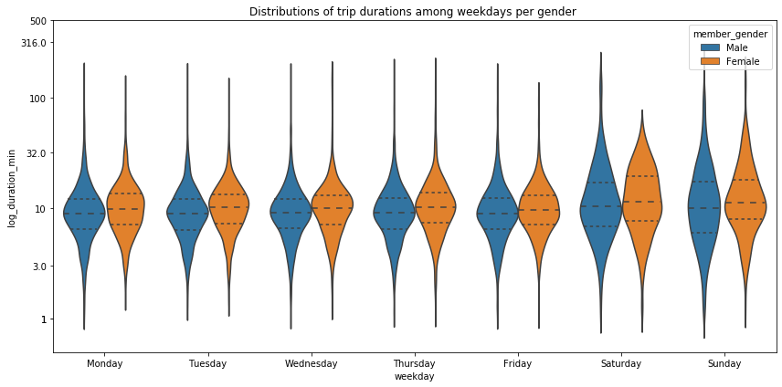

## Trip Durations among Weekdays per User Type

Average trip duration for customers are longer than for subscribers and more longer during weekends. Assume that families (who are mostly are customers) are enjoying riding during holidays.

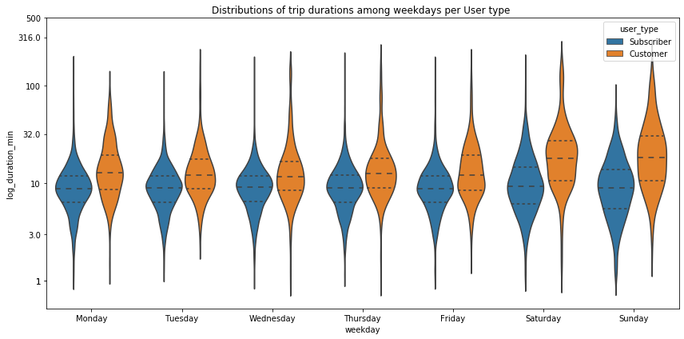